# A simulation study based on Wilcoxon Signed Rank Test

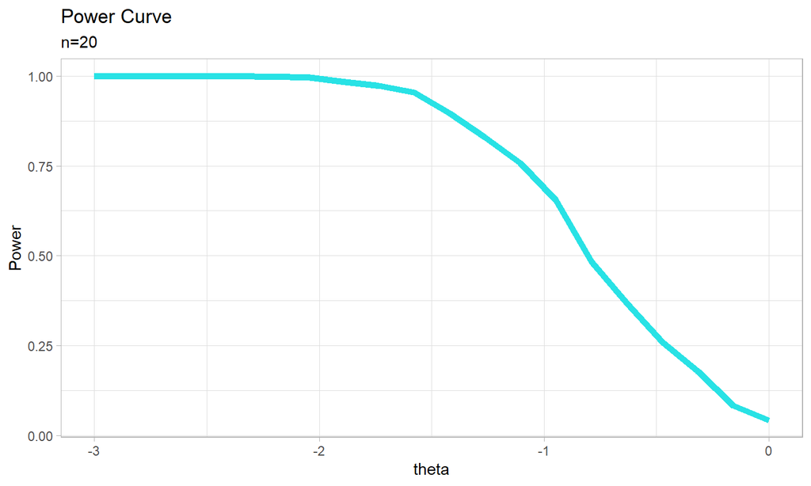

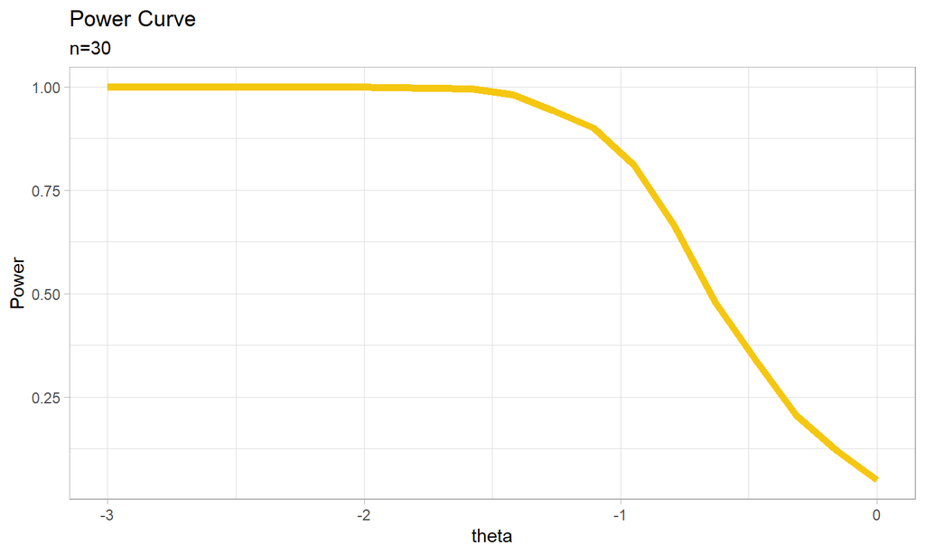

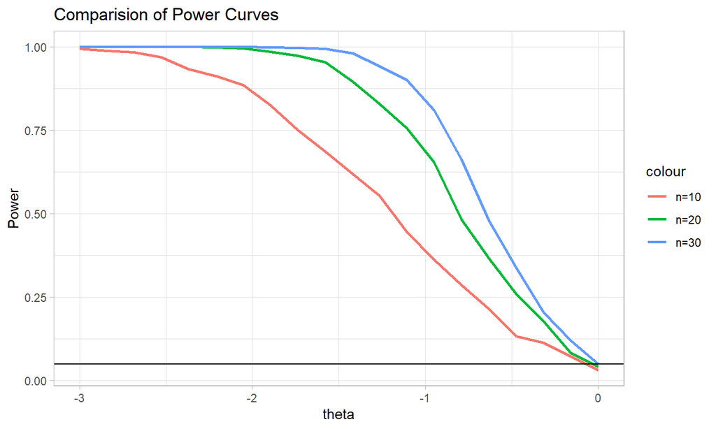

- Observation :
- For fixed theta, here samples are drawn from N($\theta$,2), power converges faster to unity with increase in sample size.
- H0 : $\theta$ = 0 vs H1 : $\theta$ $\neq$ 0

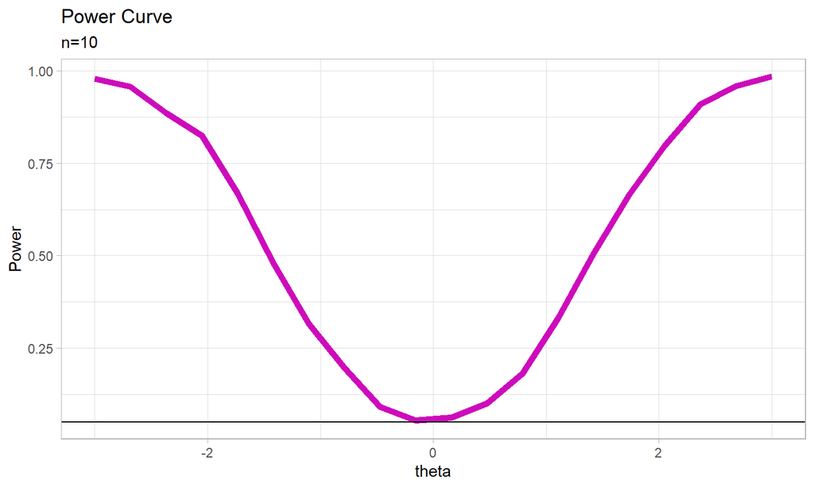

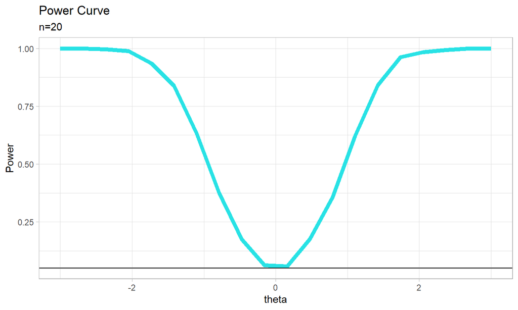

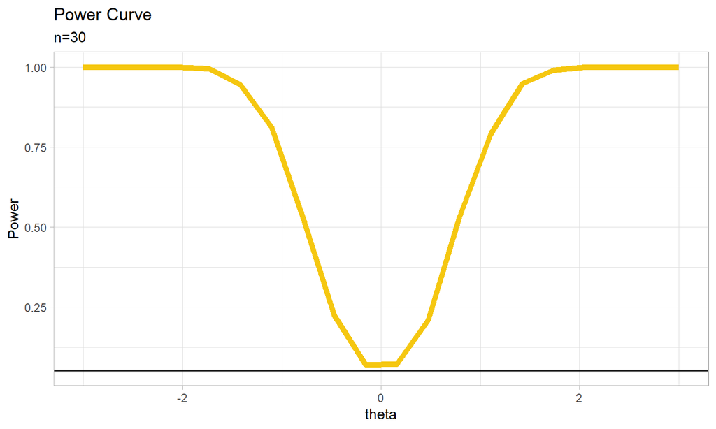

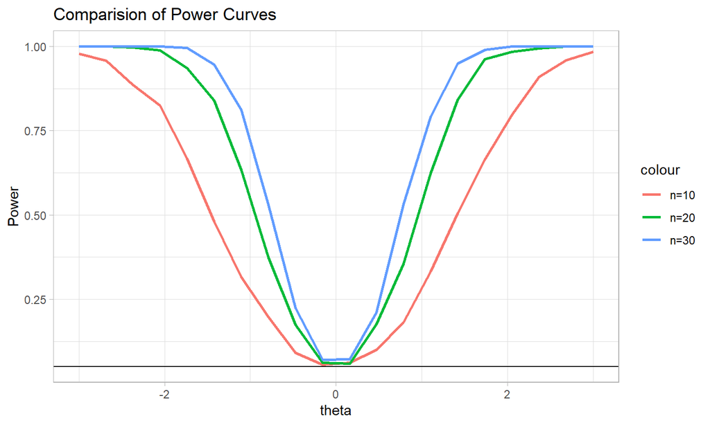

- Observation :
- For fixed theta, here samples are drawn from N($\theta$,2), power converges faster to unity with increase in sample size.
- Power Curve for varying n for fixed $\theta$ (>0)

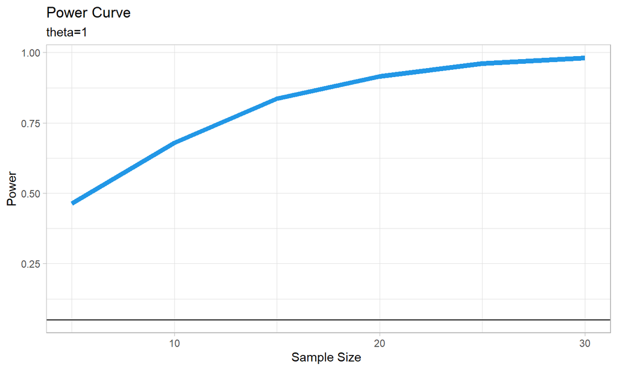

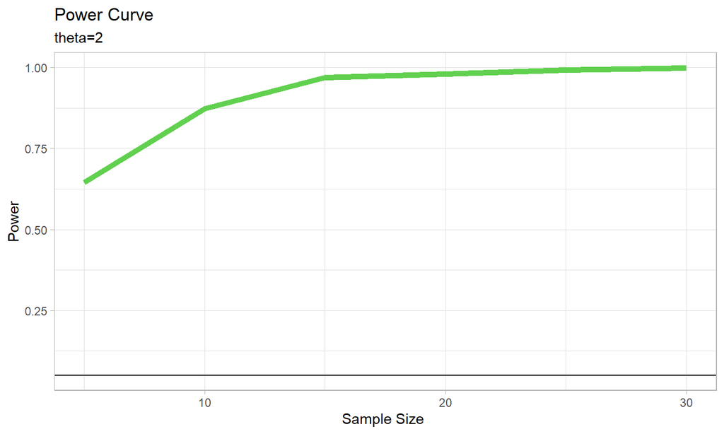

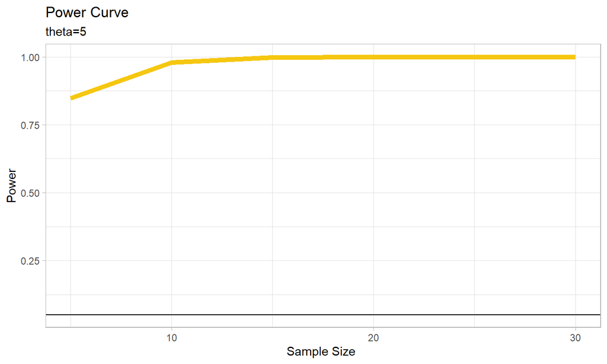

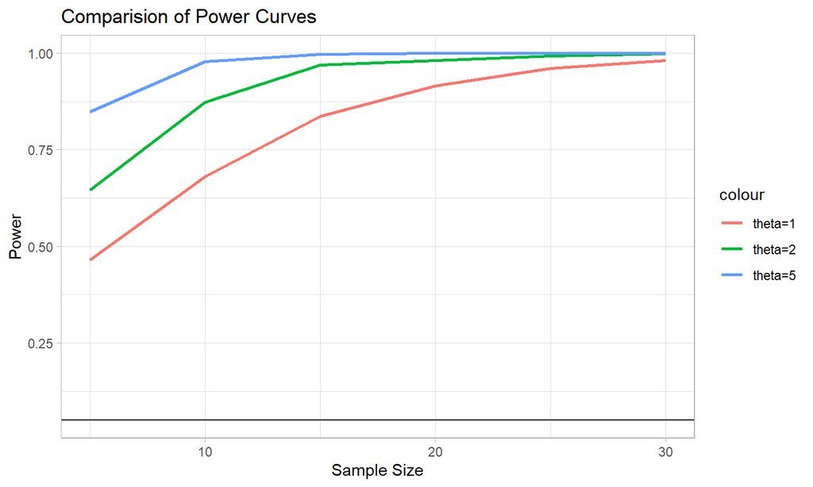

- Observation: - The more we depart from 0 , faster is the convergence of the power to unity. In other words, the power function goes to unity for smaller sample size as the value of $\theta$ increases.

- Power Curve for varying n for fixed $\theta$ (<0)

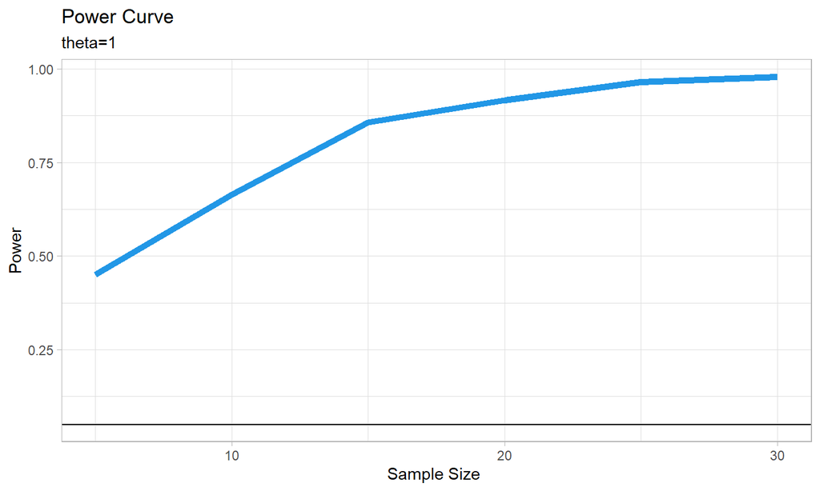

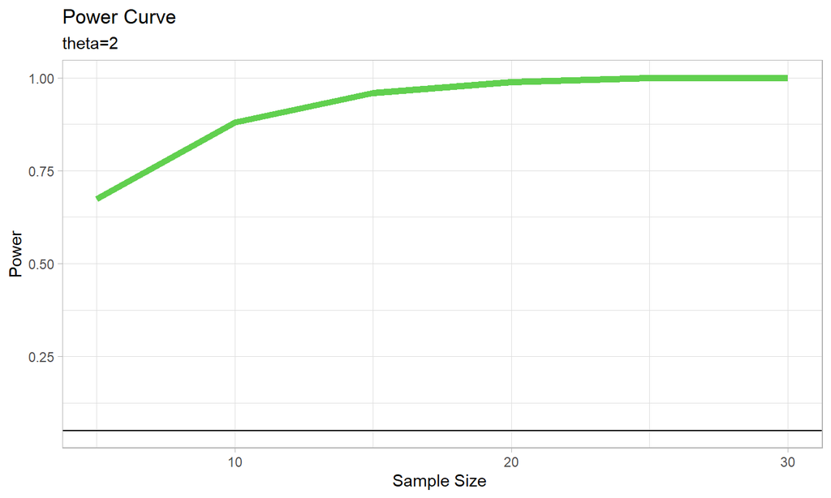

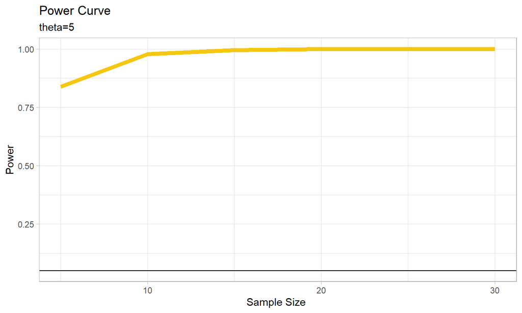

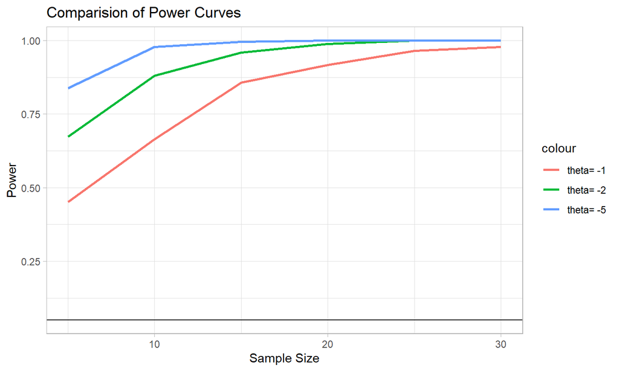

- Observation:
- The more we depart from 0 , faster is the convergence of the power to unity. In other words, the power function goes to unity for smaller sizes as the value of $\theta$ increases.

## Parametric Counterpart

- Let us consider the case when a sample of size n is drawn from N($\mu$,$\sigma$^2), $\sigma$ > 0 unknown
- H0 : $\mu$ = 0 vs H1 : $\mu$ < 0 , $\sigma$ unknown

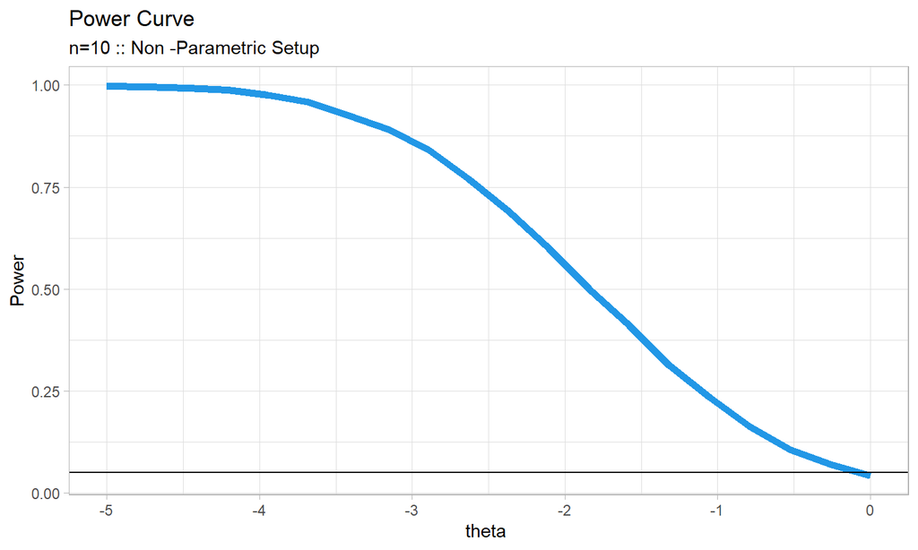

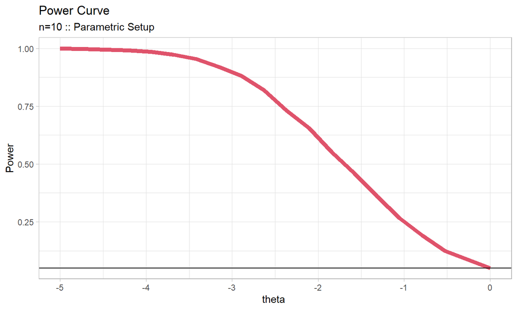

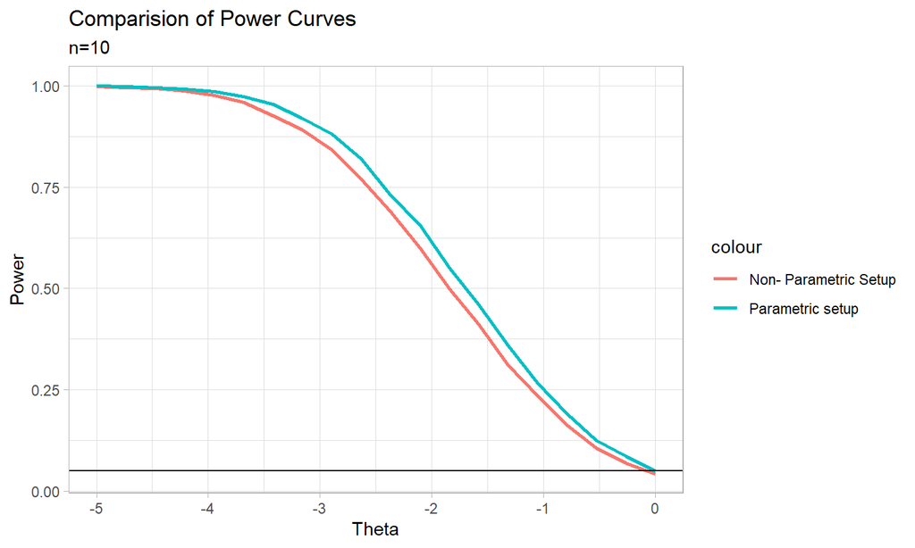

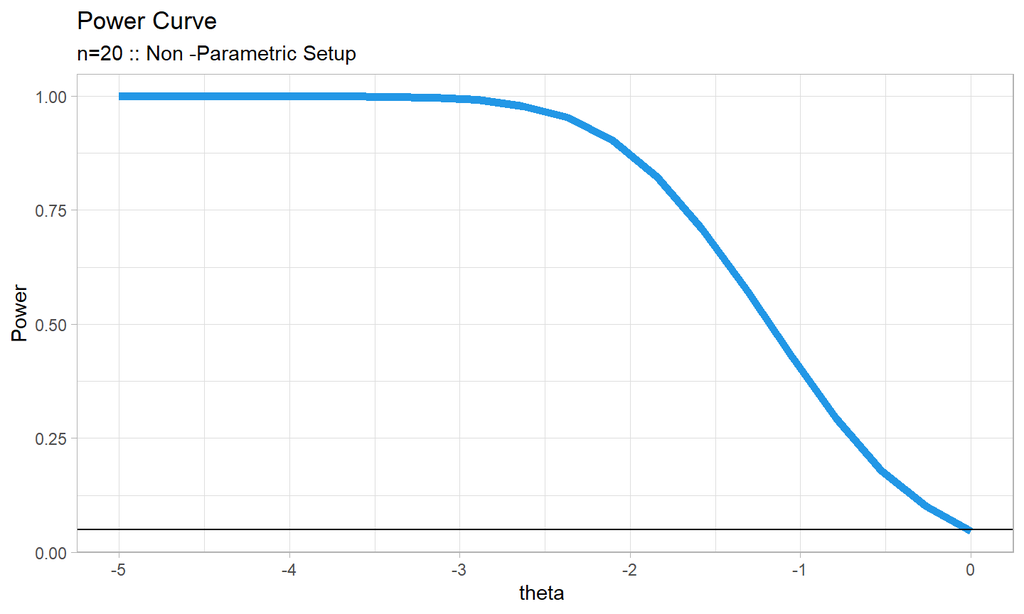

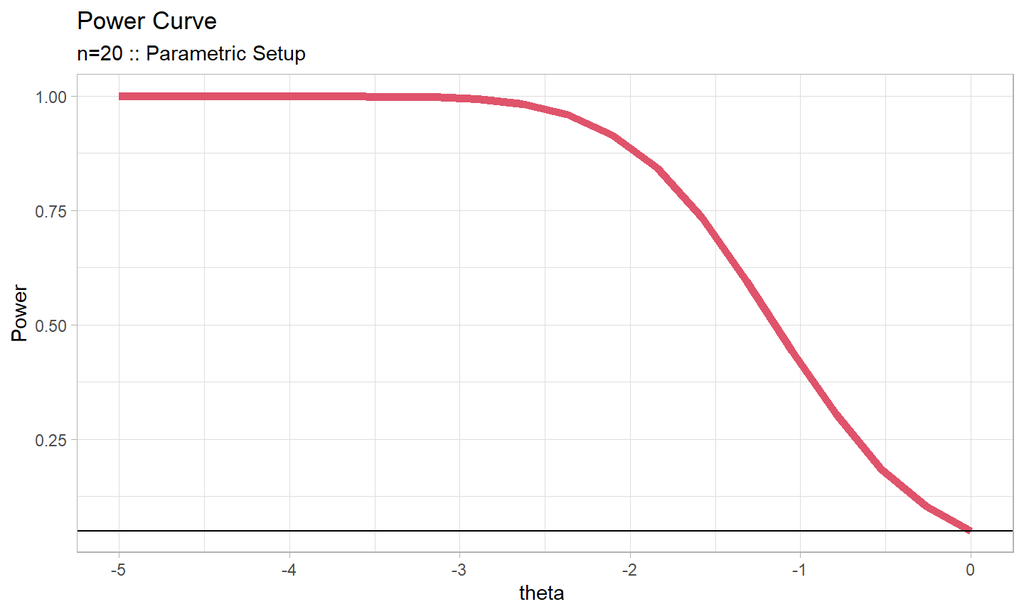

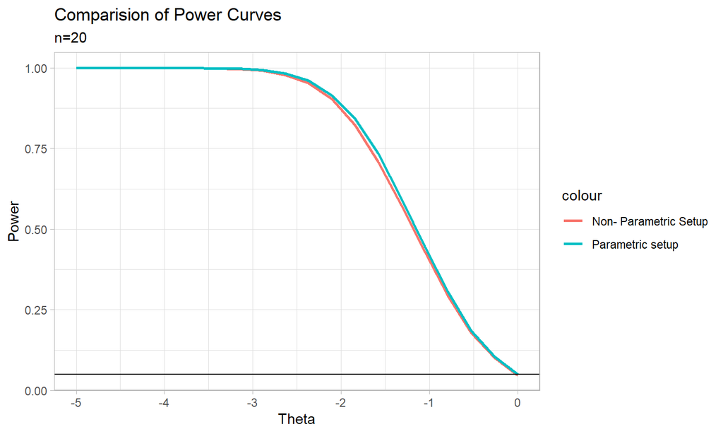

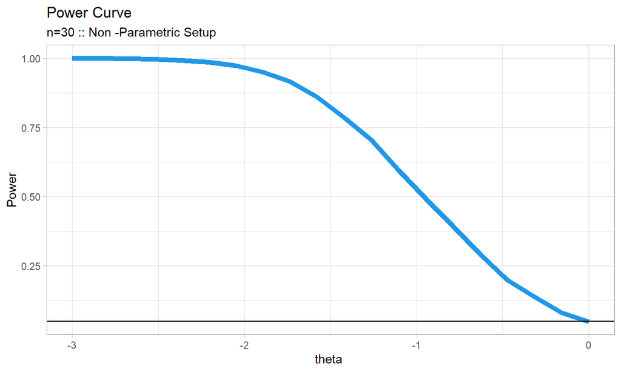

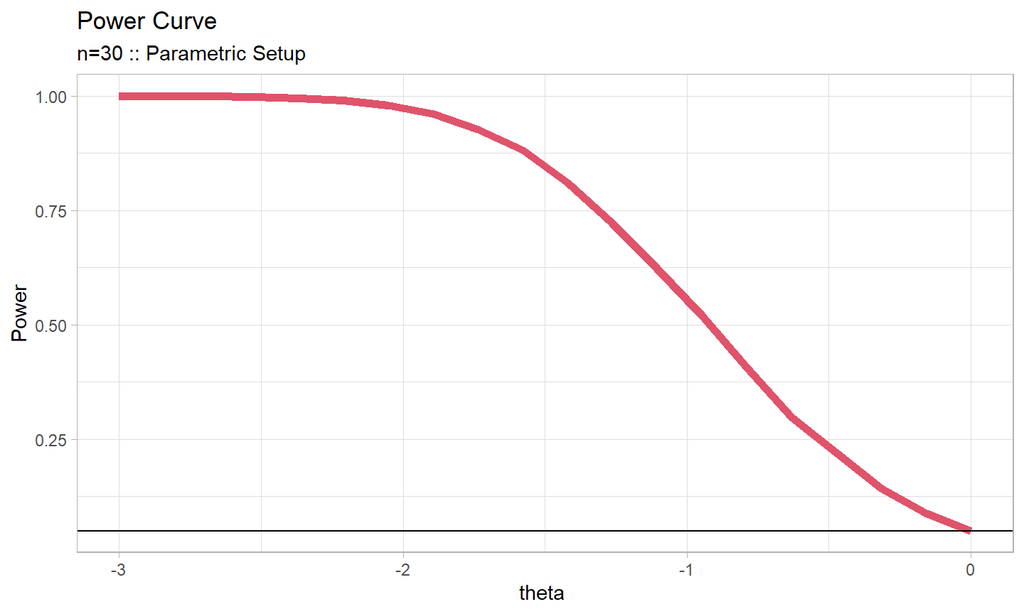

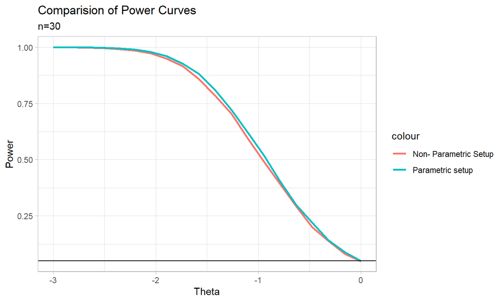

- Observation :
- Considering the t-test , the power curve for the parametric test is converging faster to unity than that of the non-parametric setup for varying sample sizes.
- Increase in sample size leads to faster rate of convergence to unity.
- Both parametric and non-parametric setup shows that the tests are unbiased.

## Parametric Counterpart

- H0 : $\mu$ = 0 vs H1 : $\mu$ > 0 , $\sigma$ unknown

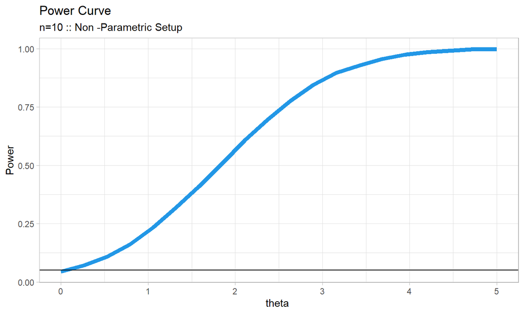

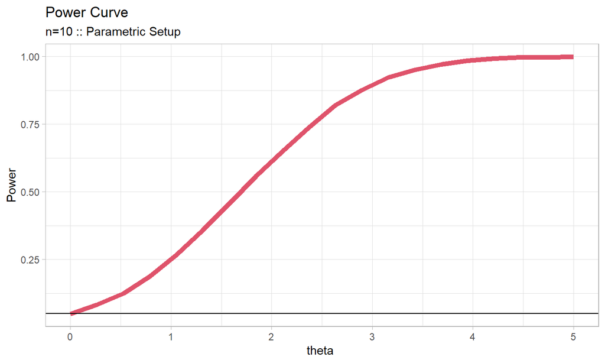

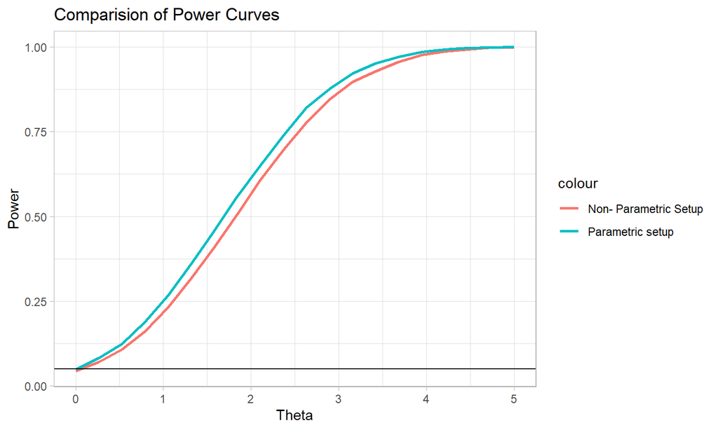

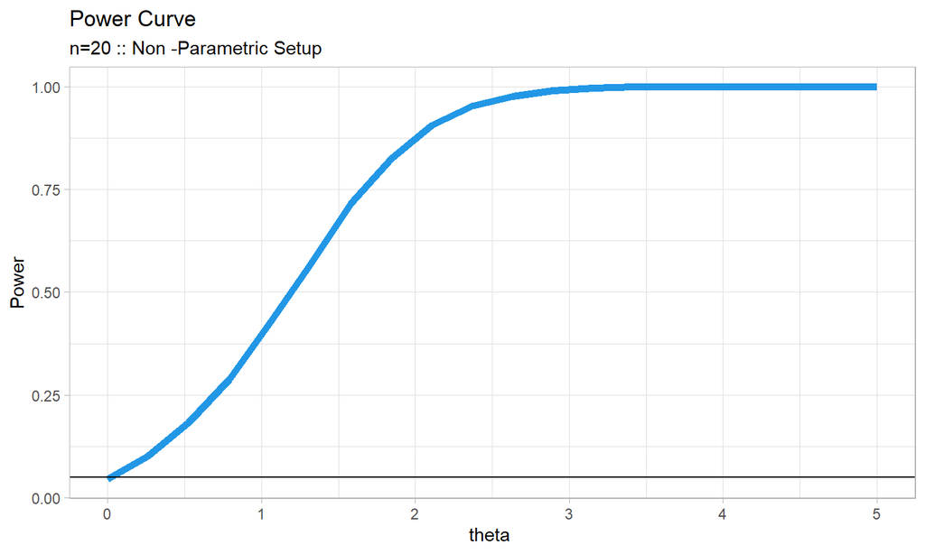

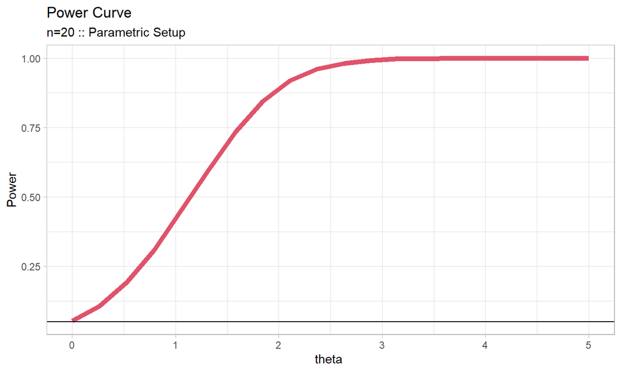